# Parameter Values for Models

# 1 Import the data

```
  NOC Year Decade     ID First.Name                   Name Last.Name Sex Age
1 AFG 1960  1960s  59346   Mohammad   Mohammad Asif Khokan    Khokan   M  24
2 AFG 1960  1960s  59043       Faiz Faiz Mohammad Khakshar  Khakshar   M  18
3 AFG 1960  1960s 109486      Abdul     Abdul Hadi Shekaib   Shekaib   M  20
  Height Weight      BMI BMI.Category        Team Population       GDP    GDPpC
1    171     78 26.67487            3 Afghanistan    8996973 537777800 59.77319
2    162     52 19.81405            0 Afghanistan    8996973 537777800 59.77319
3    178     68 21.46194            2 Afghanistan    8996973 537777800 59.77319
        Games Season City     Sport                                   Event
1 1960 Summer Summer Roma Wrestling Wrestling Men's Middleweight, Freestyle
2 1960 Summer Summer Roma Wrestling    Wrestling Men's Flyweight, Freestyle
3 1960 Summer Summer Roma Athletics              Athletics Men's 100 metres
     Medal Medal.No.Yes
1 No Medal            0
2 No Medal            0
3 No Medal            0
 [ reached 'max' / getOption("max.print") -- omitted 3 rows ]
```

```
'data.frame':   151977 obs. of  24 variables:
 $ NOC         : Factor w/ 122 levels "AFG","ALB","AND",..: 1 1 1 1 1 1 1 1 1 1 ...
 $ Year        : int  1960 1960 1960 1960 1960 1960 1960 1960 1960 1960 ...
 $ Decade      : Factor w/ 6 levels "1960s","1970s",..: 1 1 1 1 1 1 1 1 1 1 ...
 $ ID          : int  59346 59043 109486 59102 128736 29626 39922 106372 128736 58364 ...
 $ First.Name  : Factor w/ 14118 levels "","A","A.","Aadam",..: 8716 3731 64 599 64 11978 64 4634 64 8716 ...
 $ Name        : Factor w/ 74268 levels "  Gabrielle Marie \"Gabby\" Adcock (White-)",..: 48941 19066 218 3341 220 64832 215 23793 220 48946 ...
 $ Last.Name   : Factor w/ 47370 levels "","-)","-Alard)",..: 23228 23112 38893 23137 44908 13260 16633 37860 44908 22890 ...
 $ Sex         : Factor w/ 2 levels "F","M": 2 2 2 2 2 2 2 2 2 2 ...
 $ Age         : int  24 18 20 35 20 28 22 23 20 20 ...
 $ Height      : int  171 162 178 166 179 168 172 170 179 166 ...
 $ Weight      : num  78 52 68 66 75 73 70 58 75 62 ...
 $ BMI         : num  26.7 19.8 21.5 24 23.4 ...
 $ BMI.Category: Factor w/ 5 levels "0","1","2","3",..: 4 1 3 3 3 4 3 3 3 3 ...
 $ Team        : Factor w/ 332 levels "Acipactli","Afghanistan",..: 2 2 2 2 2 2 2 2 2 2 ...
 $ Population  : int  8996973 8996973 8996973 8996973 8996973 8996973 8996973 8996973 8996973 8996973 ...
 $ GDP         : num  5.38e+08 5.38e+08 5.38e+08 5.38e+08 5.38e+08 ...
 $ GDPpC       : num  59.8 59.8 59.8 59.8 59.8 ...
 $ Games       : Factor w/ 30 levels "1960 Summer",..: 1 1 1 1 1 1 1 1 1 1 ...
 $ Season      : Factor w/ 2 levels "Summer","Winter": 1 1 1 1 1 1 1 1 1 1 ...
 $ City        : Factor w/ 29 levels "Albertville",..: 19 19 19 19 19 19 19 19 19 19 ...
 $ Sport       : Factor w/ 51 levels "Alpine Skiing",..: 51 51 3 51 3 51 3 3 3 51 ...
 $ Event       : Factor w/ 489 levels "Alpine Skiing Men's Combined",..: 478 468 17 476 33 482 22 24 18 466 ...
 $ Medal       : Factor w/ 4 levels "Bronze","Gold",..: 3 3 3 3 3 3 3 3 3 3 ...
 $ Medal.No.Yes: Factor w/ 2 levels "0","1": 1 1 1 1 1 1 1 1 1 1 ...
```

Number of sports per year at the https://www.topendsports.com/events/summer/sports/number.htm<sup>1</sup>

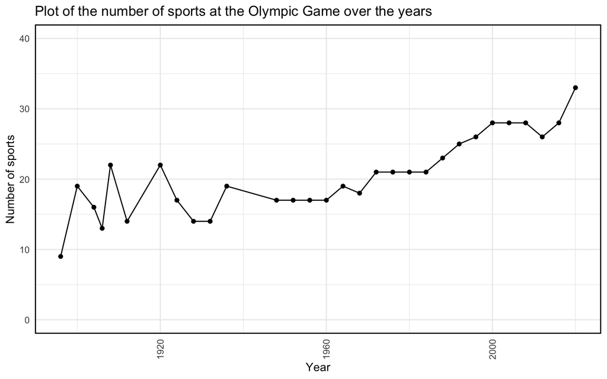

There is clearly an upward trend, but no seasonal pattern. The data is also a little choppy at the beginning. Part of the explanation is that the data points are not evenly spaced. Most Olympic games are 4 years apart, but a few of them are just 2 years apart, and during World War I and World War II there were 8-year and 12-year gaps, respectively. Since time series data should be evenly spaced over time, we’ll only look at data from 1948 on, when the Olympics started being held every 4 years without any interruptions.

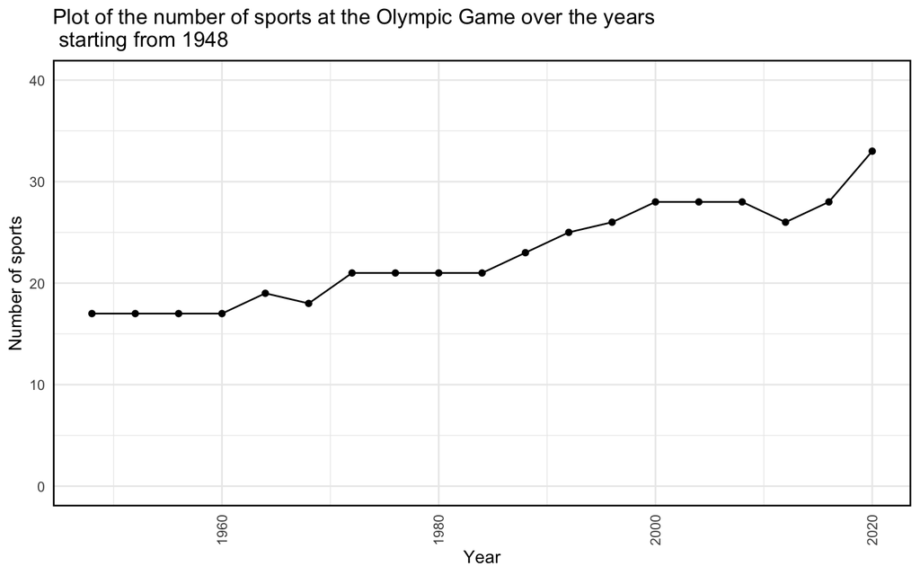

# 2 Creating models

I’m going to try 4 different models.

$$y_{\text{linear}}(x) = ax+b \\
y_{\text{quadratic}}(x) = ax^2 + bx + c \\
y_{\text{cubic}}(x) = ax^3 + bx^2 + cx + d \\
y_{\text{exponential}}(x) = a\exp(bx) + c$$

## 2.1 Chi-square “rule of thumb”

We consider $m$ equations that relate the $n$ random variables with values

$$y_j = f(a_1,...,a_m,x_j) + \epsilon_j, ~~~~~ j = 1,...,n$$

If we assume that only the $n-m$ random variables can fluctuate independently, and that the data uncertainties follow a Normal distribution, then the resulting chi-square is expected to be distributed according to

$$\chi^2_{\nu}, ~~~~~ \nu = n - m$$

Which we can compare to the “rule of thumb”, which is

$$\text{if } \frac{\chi^2}{n-m} \approx 1 ~~~ \text{where }\nu = n - m \implies \text{ "a good fit"}$$

If we have $\nu$ independent RVs and the $x_i$ are each normally distributed with mean $\mu_i$ and variance $\sigma1_i^2$, then the chi-square is,

$$\frac{\chi^2}{n-m} = \frac{\sum_{i=1}^{\nu} (x_i-\mu_i)^2/\sigma_i^2}{n-m}$$

where $n$ is the length of our y data and $m$ is the degree of the polynomial. Using the above equation, we can calculate the values for our $\chi^2$ “rule of thumb”.

## 2.2 Model Fits

```
Formula: ydata ~ lin_func(xdata, a1, b1)

Parameters:
     Estimate Std. Error t value Pr(>|t|)
a1    0.20658    0.01466   14.09 8.33e-11 ***
b1 -387.01053   29.09204  -13.30 2.05e-10 ***
---
Signif. codes:  0 '***' 0.001 '**' 0.01 '*' 0.05 '.' 0.1 ' ' 1

Residual standard error: 1.4 on 17 degrees of freedom

Number of iterations to convergence: 2
Achieved convergence tolerance: 1.49e-08
```

```
Call:
lm(formula = Num.Sports ~ Year, data = use_dat)

Residuals:
    Min      1Q  Median      3Q     Max
-2.6263 -0.9500  0.2000  0.7237  2.7210

Coefficients:
              Estimate Std. Error t value Pr(>|t|)
(Intercept) -387.01053   29.09204  -13.30 2.05e-10 ***
Year           0.20658    0.01466   14.09 8.33e-11 ***
---
Signif. codes:  0 '***' 0.001 '**' 0.01 '*' 0.05 '.' 0.1 ' ' 1

Residual standard error: 1.4 on 17 degrees of freedom
Multiple R-squared:  0.9211,    Adjusted R-squared:  0.9165
F-statistic: 198.5 on 1 and 17 DF,  p-value: 8.332e-11
```

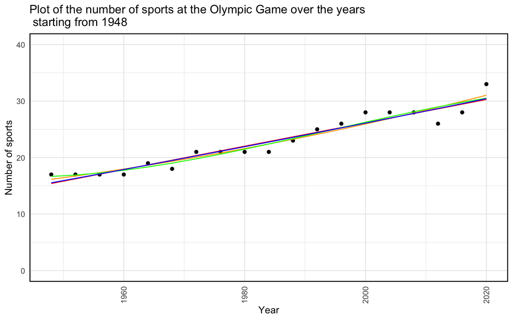

| Models | Res.Df | Res.Sum Sq | Df | Sum Sq | F value | Pr(>F) |
| --- | --- | --- | --- | --- | --- | --- |
| Linear | 17 | 33.33158 | NA | NA | NA | NA |
| Exponential | 16 | 32.28073 | 1 | 1.050847 | 0.5208539 | 0.4808924 |

| Models | Res.Df | Res.Sum Sq | Df | Sum Sq | F value | Pr(>F) |
| --- | --- | --- | --- | --- | --- | --- |
| Linear | 17 | 33.33158 | NA | NA | NA | NA |
| Quadratic | 16 | 30.41244 | 1 | 2.919136 | 1.5357588 | 0.2331213 |
| Cubic | 15 | 29.04971 | 1 | 1.362737 | 0.7036577 | 0.4147260 |

```
# A tibble: 1 x 1
   stat
  <dbl>
1   152
```

# 3 Swiming

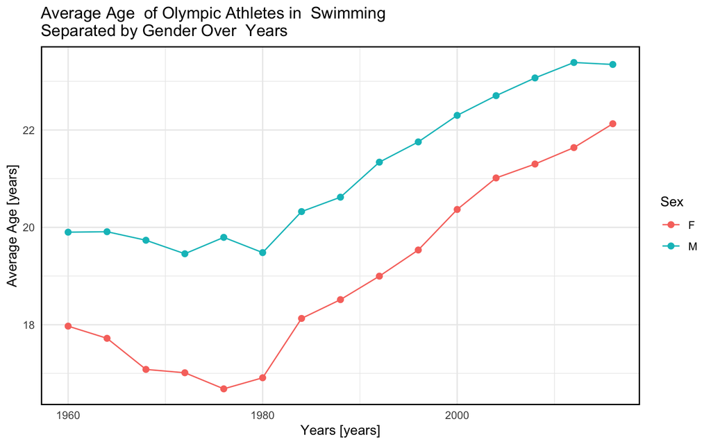

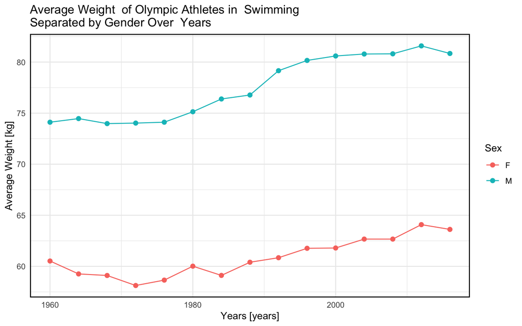

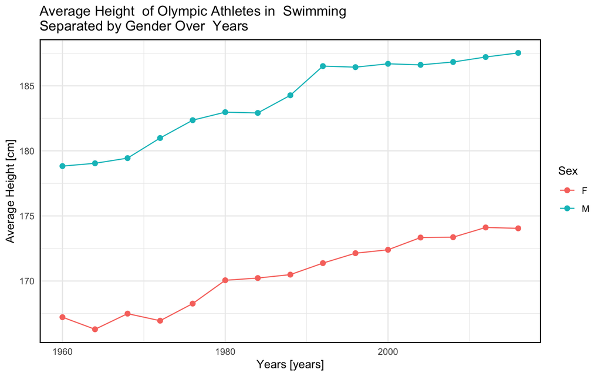

## 3.1 Female Swimmers

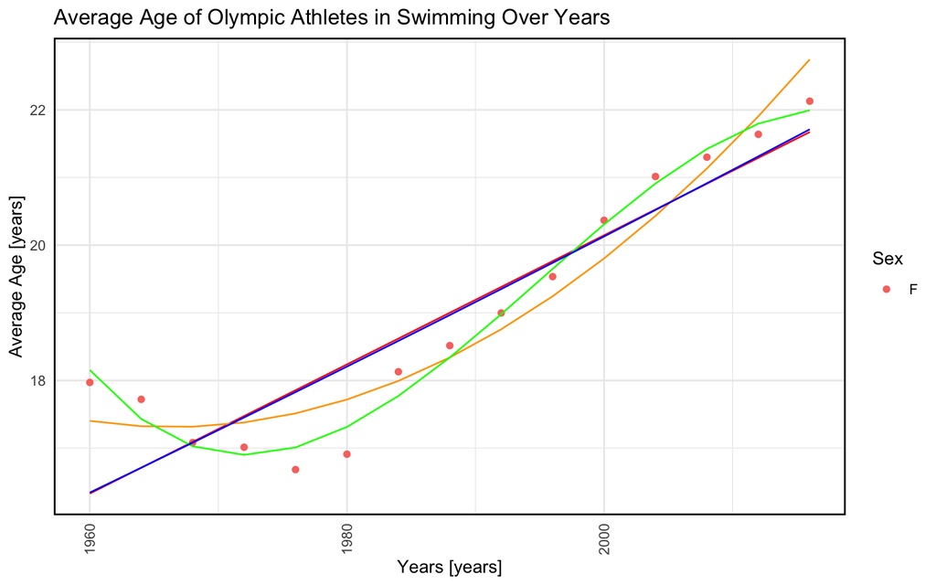

| Models | Res.Df | Res.Sum Sq | Df | Sum Sq | F value | Pr(>F) |
| --- | --- | --- | --- | --- | --- | --- |
| Linear | 13 | 8.508555 | NA | NA | NA | NA |
| Exponential | 12 | 8.161454 | 1 | 0.3471001 | 0.5103504 | 0.4886515 |

| Models | Res.Df | Res.Sum Sq | Df | Sum Sq | F value | Pr(>F) |
| --- | --- | --- | --- | --- | --- | --- |
| Linear | 13 | 8.5085546 | NA | NA | NA | NA |
| Quadratic | 12 | 3.3398817 | 1 | 5.168673 | 18.57074 | 0.0010150 |
| Cubic | 11 | 0.6470143 | 1 | 2.692867 | 45.78190 | 0.0000309 |

# References

<sup>1</sup> R. Wood, (2010).

Izzy Illari

01 May, 2020